# Using [IPUMS USA](https://usa.ipums.org/usa/) for Estimation of Population Characteristics in Various Geographic Areas

Corey S. Sparks, Ph.D. - University of Texas at San Antonio

14 April, 2021

In this example we will use the [IPUMS USA](https://usa.ipums.org/usa/) data to produce survey-based estimates for various geographic levels present in the IPUMS. This example uses the 2014-2018 ACS 5-year microdata.

The good folks at IPUMS have created a library to read in their data from the .gz file that you download. Be sure you right click and save the DDI codebook when you create your extract

This will save the xml file that contains all the information on the data (what is contained in the data file) to your computer. When using IPUMS, it will have a name like `usa_xxxxx.xml` where the x’s represent the extract number (I’m on 92 as of today).

Be sure the `ipumsr` package is installed.

```r
library(ipumsr)
ddi <- read_ipums_ddi("~/OneDrive - University of Texas at San Antonio/classes//gis_classwork/usa_00083.xml")
data <- read_ipums_micro(ddi)
```

```
## Use of data from IPUMS-USA is subject to conditions including that users should
## cite the data appropriately. Use command `ipums_conditions()` for more details.
```

```r
data<-haven::zap_labels(data) #necessary to avoid problems with "labeled" data
```

## Load some other packages

```r
library(survey)
library(dplyr)
library(car)
library(ggplot2)
library(tigris)
library(classInt)
library(tmap)
```

### Download geographic data for Public Use Microdata Areas

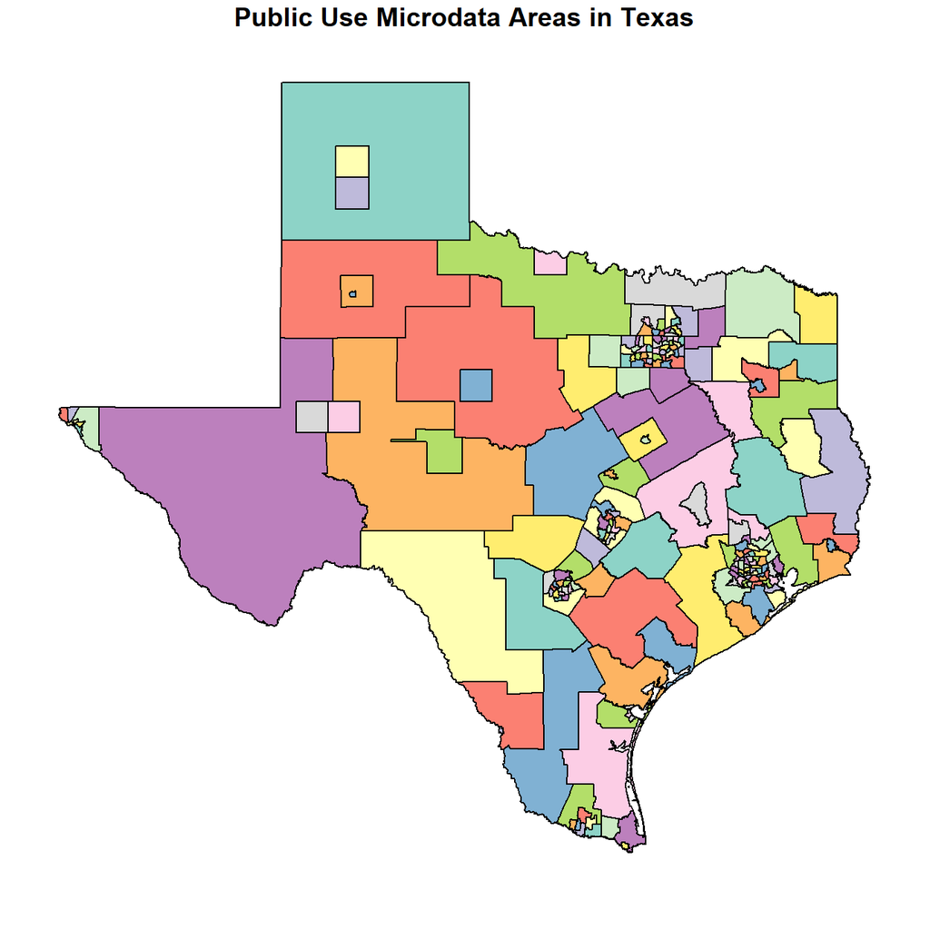

```r
options(tigris_class = "sf")
pumas<-pumas(state = "TX", year = 2018, cb = T)
plot(pumas["GEOID10"], main = "Public Use Microdata Areas in Texas")
```

```r
names(data)<-tolower(names(data))
```

## Prepare variables

Here I recode several demographic variables

```r
#weight variables, these have implied decimal places so we have to divde by 100, following the codebook
data$pwt <- data$perwt/100
data$hwt <- data$hhwt/100

#race/ethnicity
data$hisp <- Recode(data$hispan, recodes = "9=NA; 1:4='Hispanic'; 0='NonHispanic'")
data$race_rec <- Recode(data$race, recodes = "1='White'; 2='Black'; 3='Other'; 4:6='Asian'; 7:9='Other'")
data$race_eth <- interaction(data$hisp, data$race_rec, sep = "_")
data$race_eth  <- as.factor(ifelse(substr(as.character(data$race_eth),1,8) == "Hispanic", "Hispanic", as.character(data$race_eth)))
data$race_eth <- relevel(data$race_eth, ref = "NonHispanic_White")

#sex
data$male <- ifelse(data$sex == 1,1,0)

#education
data$educ_level<- Recode(data$educd, recodes = "2:61='0LT_HS';62:64='1_HSD/GED';65:80='2_somecoll';90:100='2_somecoll'; 81:83='3_AssocDegree';101='4_bachelordegree'; 110:116='4_BAplus_GradDegree'; else=NA")

#employment
data$employed <- Recode(data$wrklstwk, recodes = "1=0;2=1; else=NA")

#citizenship
data$cit<-Recode(data$citizen, recodes = "1='US born'; 2='naturalized'; 3:4='notcitizen';else=NA ")

#industry
data$ind_group<-Recode(data$ind, recodes = "170:490='ag_extract'; 770='construction'; 1070:3990='manufac'; 4070:5790='whole_retail'; 6070:6390='trans'; 6470:6780='information'; 6870:7190= 'fire'; 7270=7790='prof/sci/manage'; 7860:8470='edu/social'; 8560:8690='arts'; 8770:9290='other'; 9370:9590='public_adm'; 9670:9870='military'; else=NA ")

data$proftech <- Recode(data$ind, recodes = "7270:7490=1; 0=NA; else=0")

#age in 10 year intervals
data$agecat<-cut(data$age, breaks = c(0, 18, 20, 30, 40, 50, 65, 120), include.lowest = T)
```

## Generate survey design object

Here we identify the person weights and the survey design variables.

```r
des<-svydesign(ids = ~cluster,
               strata = ~ strata,
               weights = ~pwt,
               data = data)
```

## perform survey estimation for PUMAs

The `svyby()` function allows us calculate estimates for different **sub-domains** within the data, this could be a demographic characteristic, but we’ll use our geographic level.

```r
puma_est_edu<-svyby(formula = ~educ_level,
                    by = ~puma,
                    design = subset(des, age>25),
                    FUN=svymean,
                    na.rm = TRUE )

puma_est_employ<-svyby(formula = ~employed,
                       by = ~puma,
                       design=subset(des, age %in% 18:65),
                       FUN=svymean,
                       na.rm = TRUE )

puma_est_industry<-svyby(formula = ~proftech,
                         by = ~puma,
                         design = subset(des, employed==1),
                         FUN = svymean,
                         na.rm = TRUE )

head(puma_est_edu)
```

|  | puma | educ_level0LT_HS | educ_level1_HSD/GED | educ_level2_somecoll | educ_level3_AssocDegree | educ_level4_bachelordegree | educ_level4_BAplus_GradDegree | se.educ_level0LT_HS | se.educ_level1_HSD/GED | se.educ_level2_somecoll | se.educ_level3_AssocDegree | se.educ_level4_bachelordegree | se.educ_level4_BAplus_GradDegree |
| --- | --- | --- | --- | --- | --- | --- | --- | --- | --- | --- | --- | --- | --- |
| 100 | 100 | 0.2306312 | 0.2998785 | 0.2401108 | 0.06901725 | 0.1170781 | 0.04328419 | 0.007768013 | 0.007006647 | 0.006507094 | 0.003690006 | 0.004740205 | 0.002833496 |
| 200 | 200 | 0.2327112 | 0.2843854 | 0.2397066 | 0.07758519 | 0.1134199 | 0.05219179 | 0.010475493 | 0.009441514 | 0.008507047 | 0.005201533 | 0.006166894 | 0.004249134 |
| 300 | 300 | 0.0790213 | 0.2221511 | 0.2762901 | 0.09957680 | 0.2249961 | 0.09796460 | 0.005824892 | 0.008878513 | 0.008800368 | 0.005739117 | 0.008297903 | 0.005366460 |
| 400 | 400 | 0.2503384 | 0.3114567 | 0.2176296 | 0.06160930 | 0.1121653 | 0.04680077 | 0.008572382 | 0.008269679 | 0.007337200 | 0.003932202 | 0.005552272 | 0.003563250 |
| 501 | 501 | 0.1907592 | 0.2724265 | 0.2281626 | 0.05561138 | 0.1498042 | 0.10323620 | 0.010491265 | 0.011243987 | 0.010121276 | 0.005092057 | 0.008076961 | 0.006532522 |
| 502 | 502 | 0.1140102 | 0.2592987 | 0.2434431 | 0.07435333 | 0.1969047 | 0.11198997 | 0.006108168 | 0.008172791 | 0.007487979 | 0.004568089 | 0.006832578 | 0.005334616 |

```r
head(puma_est_employ)
```

|  | puma | employed | se |
| --- | --- | --- | --- |
| 100 | 100 | 0.7198977 | 0.007330523 |
| 200 | 200 | 0.7200376 | 0.009352539 |
| 300 | 300 | 0.7996959 | 0.008407888 |
| 400 | 400 | 0.6952739 | 0.008796408 |
| 501 | 501 | 0.7078317 | 0.012611244 |
| 502 | 502 | 0.7536922 | 0.008485558 |

```r
head(puma_est_industry)
```

|  | puma | proftech | se |
| --- | --- | --- | --- |
| 100 | 100 | 0.02736361 | 0.003251186 |
| 200 | 200 | 0.03023261 | 0.003945997 |
| 300 | 300 | 0.04936567 | 0.004513747 |
| 400 | 400 | 0.02275382 | 0.003263165 |
| 501 | 501 | 0.04444895 | 0.005380737 |
| 502 | 502 | 0.04217603 | 0.003739477 |

## join to geography

```r
pumas$puma<-as.numeric(pumas$PUMACE10)

geo1<-geo_join(pumas, puma_est_employ, by_sp="puma",by_df= "puma")
head(geo1)
```

|  | STATEFP10 | PUMACE10 | AFFGEOID10 | GEOID10 | NAME10 | LSAD10 | ALAND10 | AWATER10 | puma | employed | se | rank | geometry |
| --- | --- | --- | --- | --- | --- | --- | --- | --- | --- | --- | --- | --- | --- |
| 1 | 48 | 02310 | 7950000US4802310 | 4802310 | Dallas (Far North), Carrollton (Southeast) Cities & Addison Town--North of I-635 | P0 | 62059007 | 384841 | 2310 | 0.8255404 | 0.007484850 | 1 |  |
| 2 | 48 | 00100 | 7950000US4800100 | 4800100 | Panhandle Regional Planning Commission (Outside Potter & Randall Counties) | P0 | 61987076347 | 283632891 | 100 | 0.7198977 | 0.007330523 | 1 |  |
| 3 | 48 | 06807 | 7950000US4806807 | 4806807 | Hidalgo County (North & West) | P0 | 2563115029 | 18882358 | 6807 | 0.5847819 | 0.012739199 | 1 |  |
| 4 | 48 | 04607 | 7950000US4804607 | 4804607 | Houston City (Northeast)--Between Loop I-610 & Beltway TX-8 | P0 | 162865050 | 1371540 | 4607 | 0.6494097 | 0.011932801 | 1 |  |
| 5 | 48 | 01800 | 7950000US4801800 | 4801800 | East Texas COG (Southwest)--Henderson & Anderson Counties | P0 | 5015260440 | 233022050 | 1800 | 0.6593252 | 0.011306024 | 1 |  |
| 6 | 48 | 03900 | 7950000US4803900 | 4803900 | Deep East Texas COG (West) & Walker County | P0 | 11228402879 | 399650925 | 3900 | 0.6385985 | 0.011127962 | 1 |  |

```r
geo2<-geo_join(pumas, puma_est_industry, by_sp="puma",by_df= "puma")
head(geo2)
```

|  | STATEFP10 | PUMACE10 | AFFGEOID10 | GEOID10 | NAME10 | LSAD10 | ALAND10 | AWATER10 | puma | proftech | se | rank | geometry |
| --- | --- | --- | --- | --- | --- | --- | --- | --- | --- | --- | --- | --- | --- |
| 1 | 48 | 02310 | 7950000US4802310 | 4802310 | Dallas (Far North), Carrollton (Southeast) Cities & Addison Town--North of I-635 | P0 | 62059007 | 384841 | 2310 | 0.11304911 | 0.006613145 | 1 |  |
| 2 | 48 | 00100 | 7950000US4800100 | 4800100 | Panhandle Regional Planning Commission (Outside Potter & Randall Counties) | P0 | 61987076347 | 283632891 | 100 | 0.02736361 | 0.003251186 | 1 |  |
| 3 | 48 | 06807 | 7950000US4806807 | 4806807 | Hidalgo County (North & West) | P0 | 2563115029 | 18882358 | 6807 | 0.02075907 | 0.005035484 | 1 |  |
| 4 | 48 | 04607 | 7950000US4804607 | 4804607 | Houston City (Northeast)--Between Loop I-610 & Beltway TX-8 | P0 | 162865050 | 1371540 | 4607 | 0.05018302 | 0.008432400 | 1 |  |
| 5 | 48 | 01800 | 7950000US4801800 | 4801800 | East Texas COG (Southwest)--Henderson & Anderson Counties | P0 | 5015260440 | 233022050 | 1800 | 0.03392626 | 0.005050893 | 1 |  |
| 6 | 48 | 03900 | 7950000US4803900 | 4803900 | Deep East Texas COG (West) & Walker County | P0 | 11228402879 | 399650925 | 3900 | 0.03434501 | 0.005067912 | 1 |  |